# Estimation locale de l’I-C Ratio

# 1 Rappels théoriques

## 1.1 Régression non paramétrique

La régression locale est un cas particulier de la régression non paramétrique.

Supposons que l’on ait un ensemble de points $(x_i,y_i)_{1\leq i\leq n}$. La régression non paramétrique consiste à supposer qu’il existe une fonction $\mu$, à estimer, telle que $y_i=\mu(x_i)+\varepsilon_i$ avec $\varepsilon_i$ un terme d’erreur. D’après le théorème de Taylor, pour tout point $x_0$, si $\mu$ est différentiable $d$ fois, alors :
$$\forall x \::\:\mu(x) = \mu(x_0) + \mu'(x_0)(x-x_0)+\dots +
\frac{\mu^{(d)}(x_0)}{d!}(x-x_0)^d+R_d(x),$$
où $R_d$ est un terme résiduel négligeable au voisinage de $x_0$. Dans un voisinage $h(x_0)$ autour de $x_0$, $\mu$ peut être approchée par un polynôme de degré $d$. La quantité $h(x_0)$ est appelée *fenêtre* (*bandwidth*). Si $\varepsilon_i$ est un bruit blanc, on peut donc estimer par les moindres carrés $\mu(x_0)$ en utilisant les observations qui sont dans $\left[x_0-h(x_0),x_0+h(x_0)\right]$.

Dans le cas de l’approximation polynomiale locale, $x=t$ et $x_0=t_1$ date à laquelle on veut estimer la tendance-cycle. En reprenant les notations de Proietti et Luati, on suppose que notre série temporelle $y_t$ peut être décomposée en
$$y_t=\mu_t+\varepsilon_t,$$
où $\mu_t$ est la tendance et $\varepsilon_{t}\overset{i.i.d}{\sim}\mathcal{N}(0,\sigma^{2})$ est le bruit.

La tendance $\mu_t$ est localement approchée par un polynôme de degré $d$, de sorte que dans un voisinage $h$ de $t$ $\mu_t\simeq m_{t}$ avec :
$$\forall j\in\left[| -h,h\right|] :\:
y_{t+j}=m_{t+j}+\varepsilon_{t+j},\quad m_{t+j}=\sum_{i=0}^{d}\beta_{i}j^{i}.$$
On a donc $\beta_0=\mu(t)$, $\beta_1=\mu'(t)$, etc.

L’estimation est faite en utilisant les WLS :
$$\hat{\beta}=(X'KX)^{1}X'Ky$$
Il vient en particulier
$$\hat{\mu}{(t)}=\hat\beta_0=e_1'\hat{\beta} =w'y=\sum_{j=-h}^{h}w_{j}y_{t-j}$$

Cela permet également d’avoir des estimations de $\mu'(t)$ :
$$\widehat{\mu'}{(t)}=\hat\beta_1=e_2'\hat{\beta} =v'y=\sum_{j=-h}^{h}v_{j}y_{t-j}$$
Attention, ce n’est pas une estimation de la pente de $\hat\mu$ : le calcul exact est plus compliqué et plus difficilement calculable.

Pour le filtre symétrique de Henderson, modéliser une tendance de degré 2 ou 3 donne les mêmes résultats mais ce n’est pas le cas pour l’estimateur de la pente. Pour l’estimateur de la dérivée seconde c’est le même résultat pour le filtre symétrique pour si l’on modélise une tendance de degré 2 ou 3.

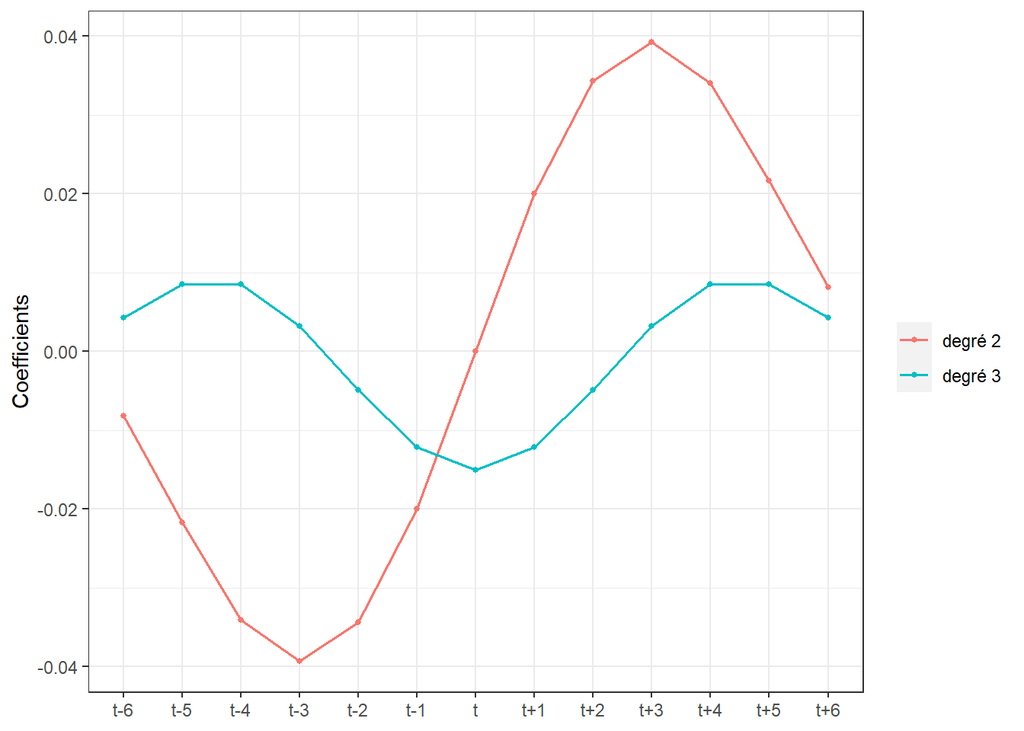

Figure 1.1: Moyenne mobile utilisée pour l’estimation de la pente pour $d=2$ et $d=3$

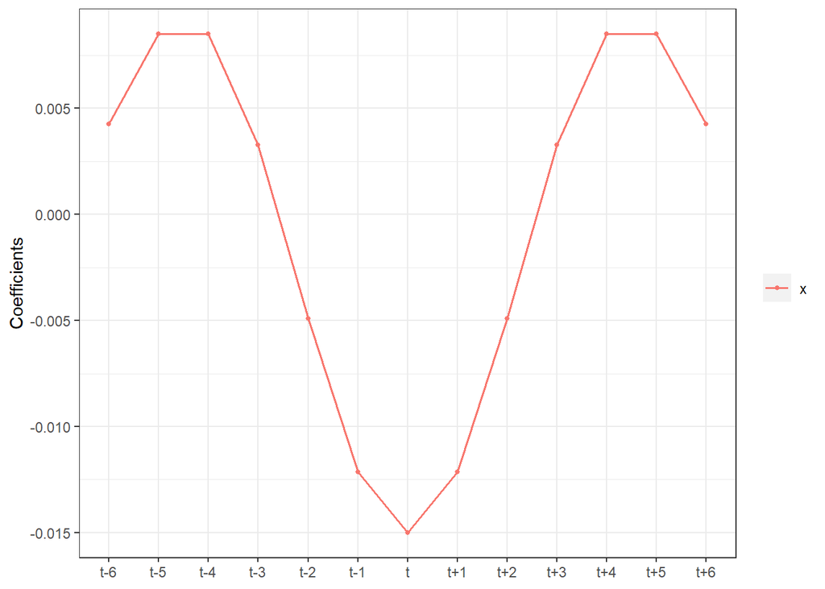

Figure 1.2: Moyenne mobile utilisée pour l’estimation de la dérivée seconde

## 1.2 Cas asymétrique

Prenons le cas du filtre asymétrique de Musgrave. On suppose qu’en fin de période la tendance peut s’approcher par une droite :
$$y_t=\gamma_0+\delta_1t+\varepsilon_t,\quad\varepsilon_t\sim\mathcal N(0,\sigma^2)$$
et on suppose que le filtre asymétrique ne préserve les constantes sans biais. Le filtre asymétrique est obtenu en minimisant les révisions au filtre symétrique en ne préservant que les constantes. On peut montrer qu’il y a un degré de liberté qui est le ratio $\delta_1^2/\sigma^2$.

Dans leur article, Proietti et Luati estiment ce rapport en minimisant le critère de validation croisée (je ne sais pas d’ailleurs pas exactement comment ils font ça). Mon idée est de faire une estimation locale en utilisant une estimation locale de la pente $\mu'$. Le paramètre $\sigma^2$ est estimé sur l’ensemble des données en utilisant le filtre symétrique (cf Loader 1999) :

$$\hat\sigma^2 = \frac{1}{1-2w_0^2+\sum_{i=-h}^hw_i}\frac{1}{n-2h}\sum_{i=h+1}^{n-h}(y_t-\hat\mu_t)^2$$
avec $w_i$ les coefficients du filtre symétrique.

La pente peut être estimée en utilisant la moyenne mobile 1.1. L’idée est la suivante : en période de retournement conjoncturel, la pente devrait changer de signe et donc le rapport $\delta_1^2/\sigma^2$ devrait être proche de 0 au point de retournement (on fait donc une approximation par une constante). Il faudrait donc utiliser un rapport $\delta_1^2/\sigma^2$ différent pour chaque filtre asymétrique. On a déplacé le problème car pour l’estimation de la pente on utilise les anciennes estimations en $t-6$ (lorsque le filtre symétrique peut s’appliquer) et donc on suppose que la pente constante. Pour les premiers tests je vais tout d’abord voir comment se comporte les filtres en supposant que l’on peut appliquer le filtre symétrique pour estimer $\delta_1$ puis essayer différentes possibilités pour estimer la pente (le plus simple étant de faire des filtres asymétriques directs).

La même idée peut-être utilisée pour calibrer le filtre Quadratic-Linear où l’on suppose en fin de période
$$y_t=\gamma_0+\gamma_1t+\delta_2t^2+\varepsilon_t,\quad\varepsilon_t\sim\mathcal N(0,\sigma^2)$$
où $\delta_2$ peut être calibré par $2\widehat{\mu''}(t)$.

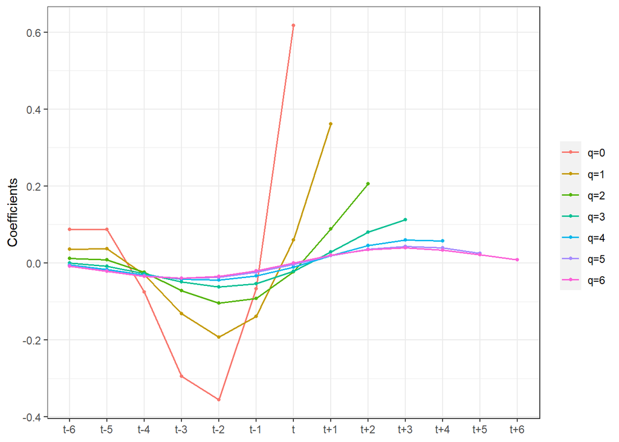

Figure 1.3: Moyenne mobile asymétriques directes pour l’estimation de la pente avec $d=2$

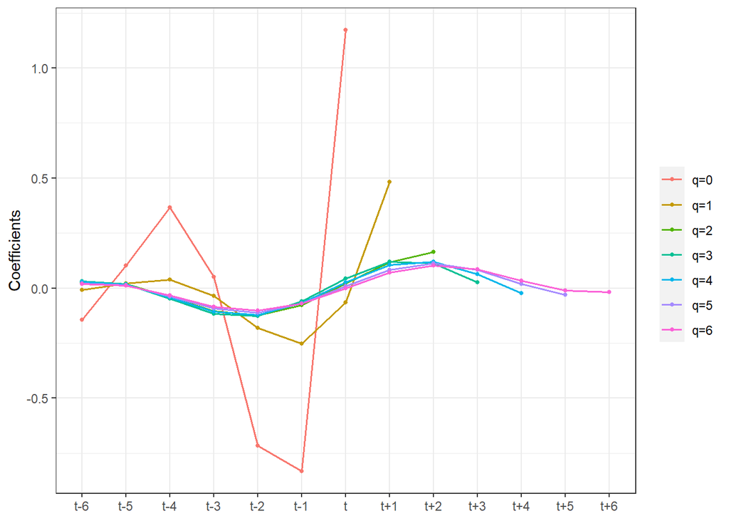

Figure 1.4: Moyenne mobile asymétriques directes pour l’estimation de la pente avec $d=3$

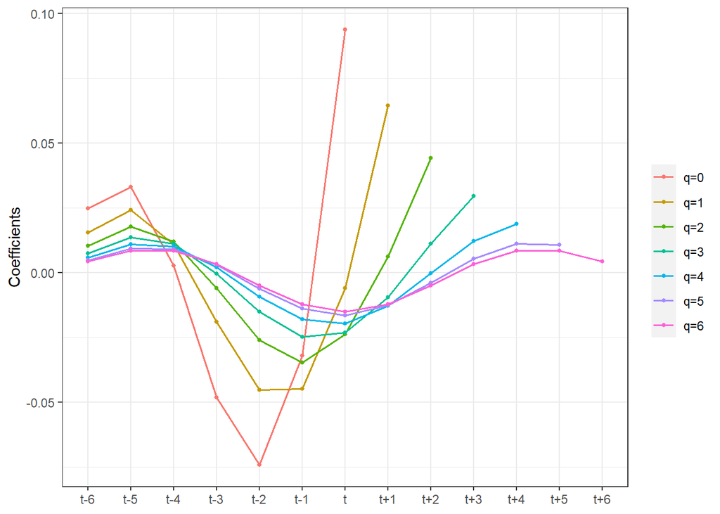

Figure 1.5: Moyenne mobile asymétriques directes pour l’estimation de la dérivée seconde avec $d=2$

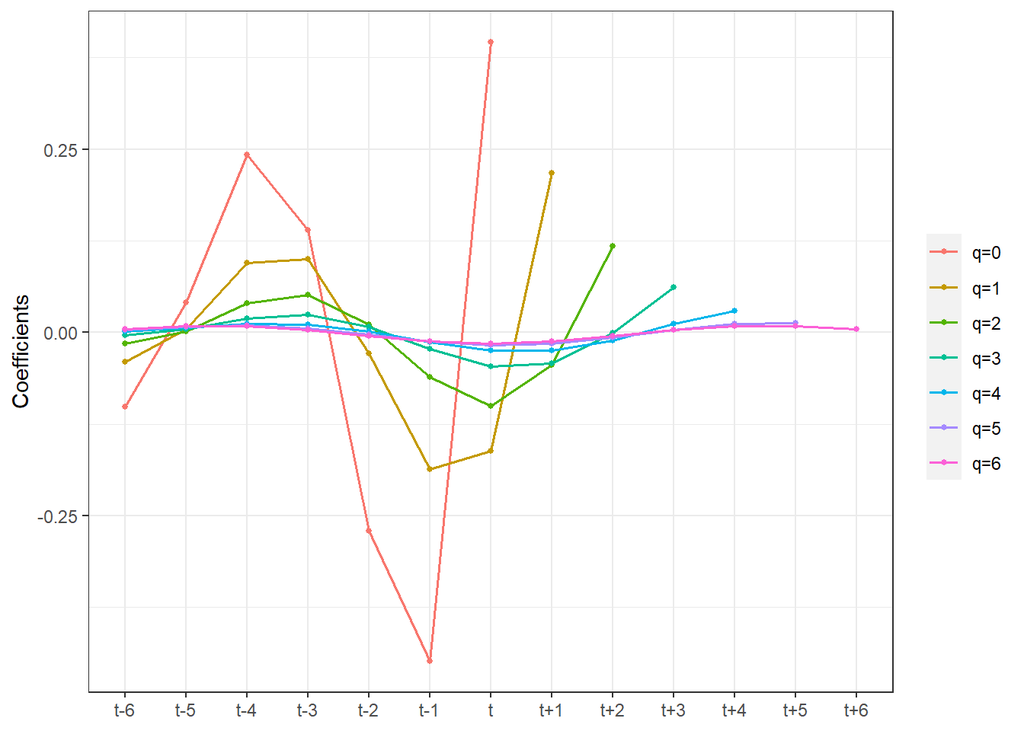

Figure 1.6: Moyenne mobile asymétriques directes pour l’estimation de la dérivée seconde avec $d=3$

[interactive chart not shown]